# Creating Good Graphics

Susan Vanderplas

2025-07-02

# Identifying the Problem

## Pie Chart Poll Results

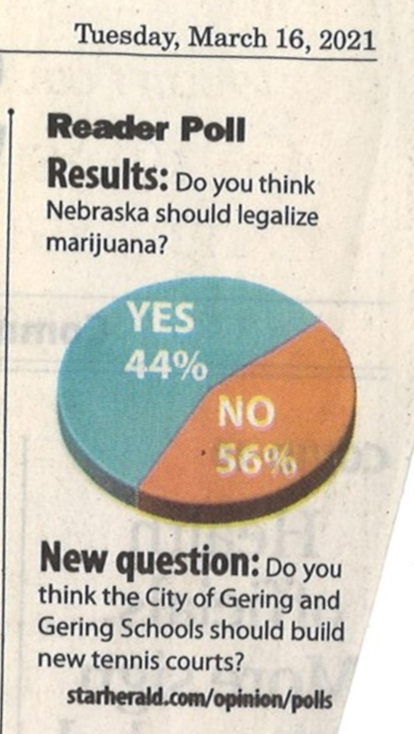

Figure 1: Scottsbluff Star Herald Reader poll. [Source](https://viz.wtf/image/646651837987061760)

- What is wrong with this chart?
- Do you think it might be misleading? If so, how?
- Do you think the mistakes were intentional?

## High Support

[figure not shown]

Figure 2: [Source](https://viz.wtf/post/143173587191/high-support)

- What is wrong with this chart?
- What would you change to more accurately represent the data?
- Do you think the mistakes were intentional?

## Gas Prices

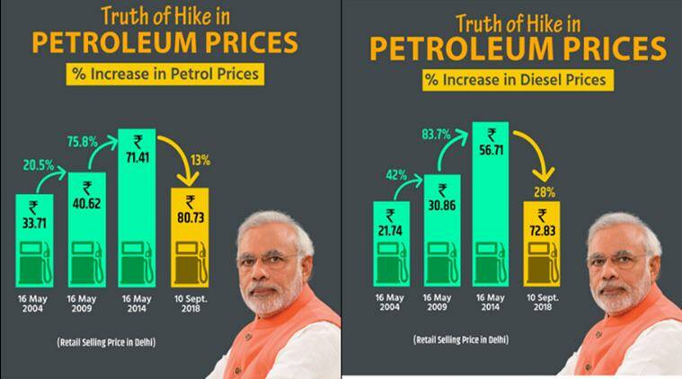

Figure 3: Gas and Diesel price changes in India (2004 - 2018).

- What is wrong with this?
- What design choices contribute to the problems?
- Do you think this was intentionally designed to be misleading? Why or why not?

## Information Overload

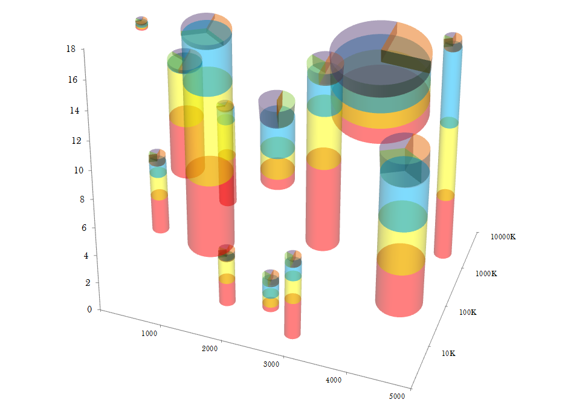

Figure 4

- What problems do you have reading this chart?
- Can you compare the quantities of all 6 variables shown? Why or why not?

(Yes, the blog this chart is taken from is satirical. This is *not* a recommended graphical form.)

# Designing Good Charts

## Why Graphics Matter

Graphics are a form of **external cognition** that allow us to think about the *data* rather than the *chart*.

That is, graphics are a tool to make it easier for us to think about what the data means.

Good graphics take advantage of how the brain works, leveraging

- preattentive processing
- perceptual grouping
- awareness of visual limitations

Good graphics also depend on the data: the chart type should be chosen based on the types of variables you want to display, the amount of data you have, and the results you want to highlight.

## Example: Hertzsprung Russell Diagram

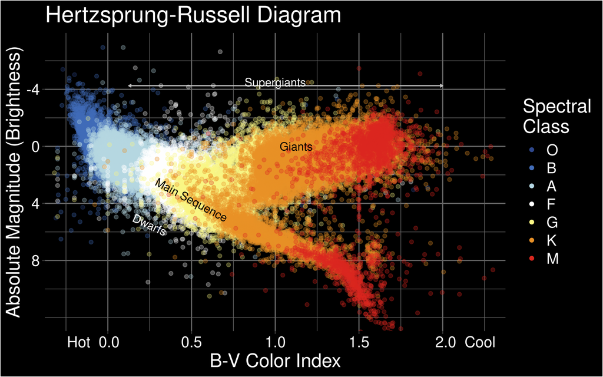

The Hertzsprung Russell diagram. Discovered independently by Ejnar Hertzsprung (1873–1967) and Henry Norris Russell (1877–1957). The diagram plots the color index of the star against the brightness (absolute magnitude) of the star. As a result, it is possible to discern that these two variables are related and change together over a star’s life cycle: a hypothesis that only came to be because of this chart.

## Preattentive Perception

- Combinations of preattentive features require attention
  - Double-encoding (using multiple features for the same variable) is ok

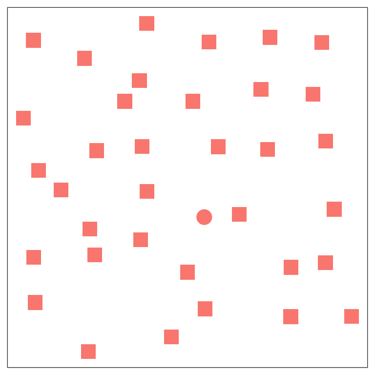

(a) Shape

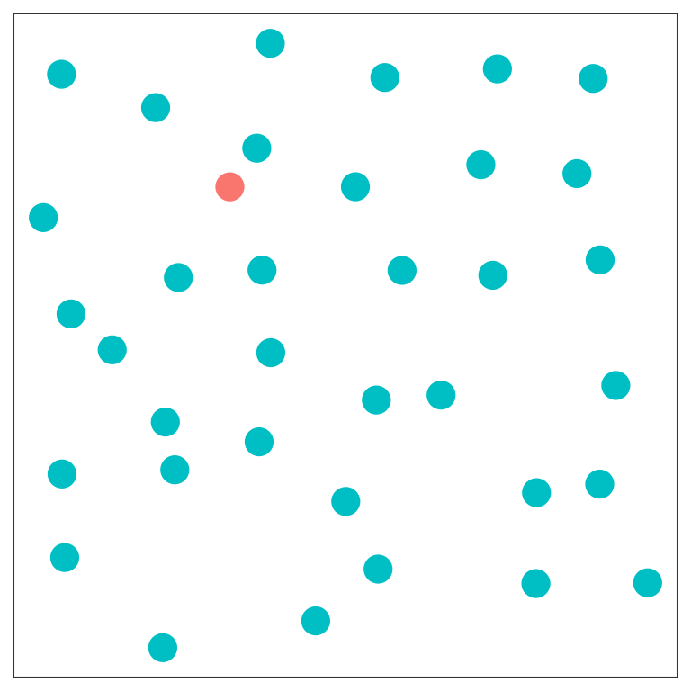

(b) Color

Figure 5: Two scatterplots with one point that is different. Can you easily spot the different point?

## Preattentive Perception

- Combinations of preattentive features require attention
  - Double-encoding (using multiple features for the same variable) is ok

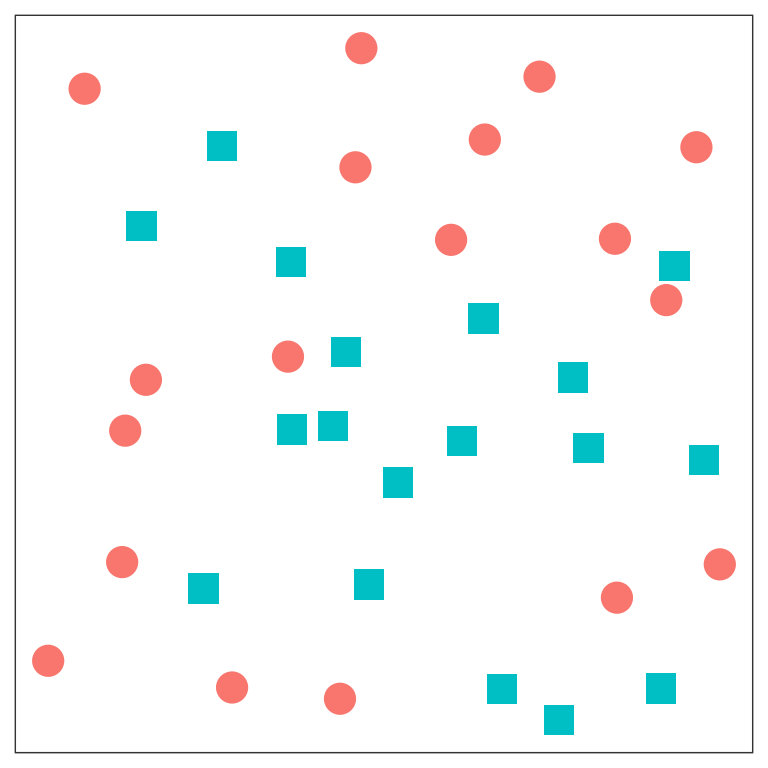

(a) Shape and Color (dual encoded)

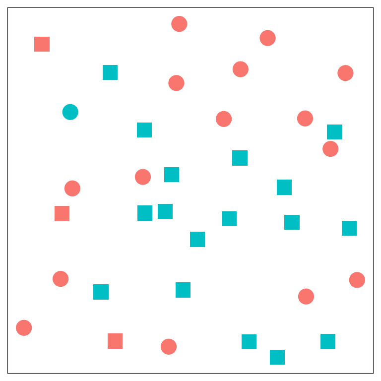

(b) Shape and Color (different variables)

Figure 6: Two scatterplots. Can you easily spot the different point(s)?

## Perceptual Grouping

[figure not shown]

Figure 7: Is this a rabbit or a duck?

[figure not shown]

Figure 8: What do you see in this image?

## Perceptual Grouping

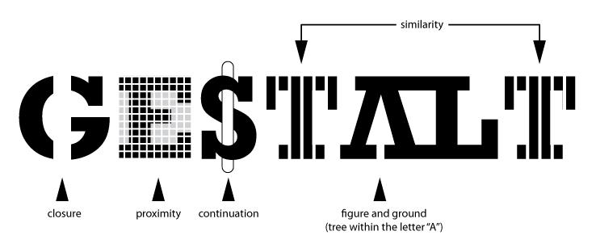

## Grouping in Charts

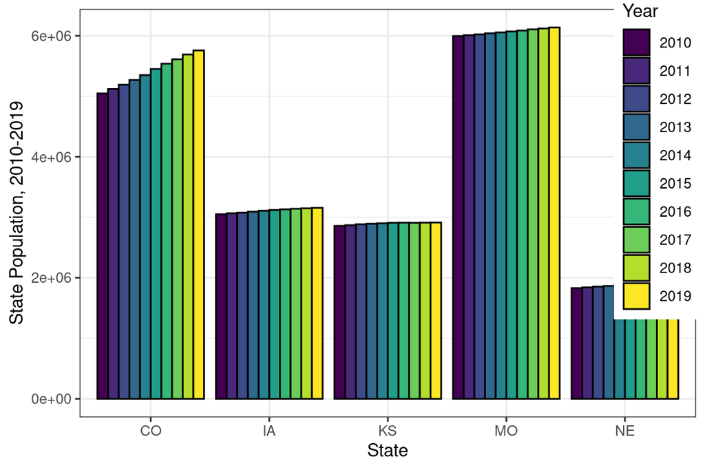

Bar chart, showing 5 states

Three versions of the same data that emphasize different aspects of the dataset.

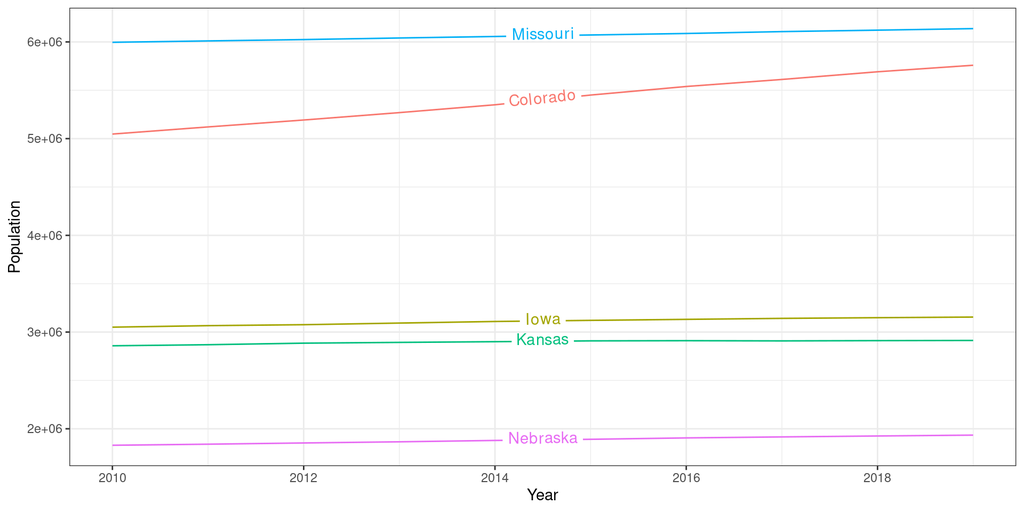

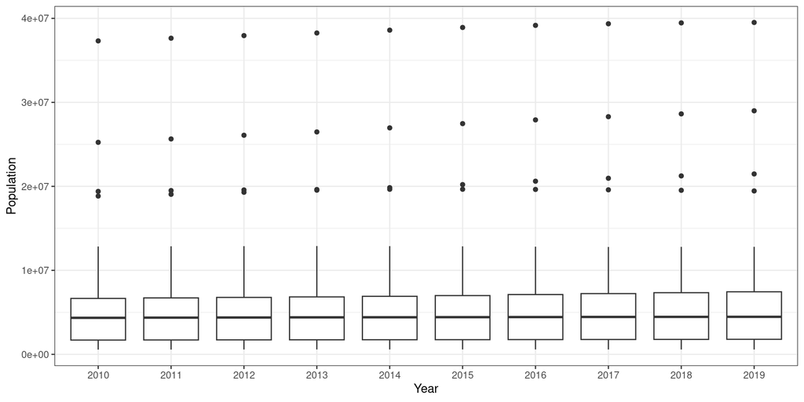

# Perceptual Limitations

## Color

- 10% of XY and 0.2% of XX have color deficiency
- Avoid rainbow color schemes
  - unequal perception of different colors (we see more shades of green) = misleading idea of distance
  - avoid “stoplight” color schemes

## Color

- Strategies
  - double encoding (color + shape or linetype)
  - make it work with black and white printers
  - use monochromatic (single color) gradients where possible
  - if you use bidirectional scale (e.g. blue to red), go through white or light yellow

## Color

- Be conscious of what some colors “mean” to use implicit understandings
- Avoid pink = female, blue = male

## Working Memory

- you can remember between 5 and 9 (7 plus or minus 2) things without writing them down
- Avoid legends that have more than 7 categories

## Accessibility

- Provide alt-text for your charts: describe the important information, the data source and how the information is represented
- Use larger text to make it easy for people with vis deficiencies to read
- Some fonts are easier for people with dyslexia to read – if you’re working with someone with dyslexia, ask them what font they prefer.